# IRIS

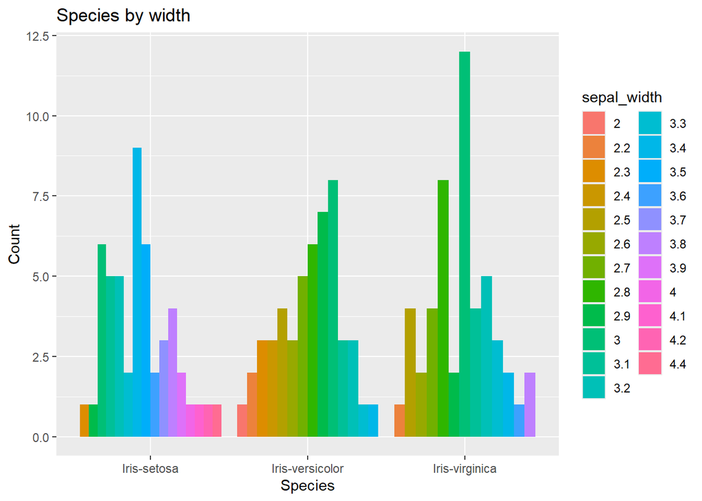

```r
ggplot(iris, aes(x= factor(species), fill= factor(sepal_width)))+
  geom_bar(position = "dodge")+
  labs(x= "Species", y= "Count", fill= "sepal_width")+
  ggtitle("Species by width")
```

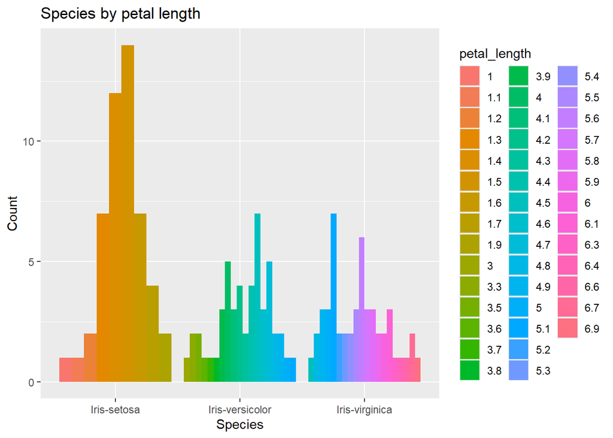

```r
ggplot(iris, aes(x= factor(species), fill= factor(petal_length)))+
  geom_bar(position = "dodge")+
  labs(x= "Species", y= "Count", fill= "petal_length")+
  ggtitle("Species by petal length")
```

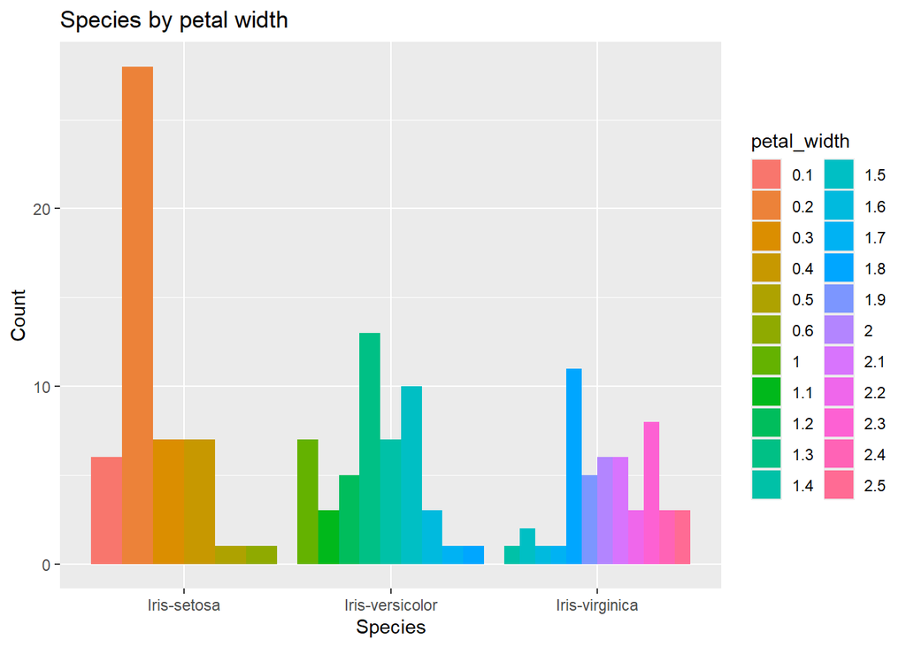

```r
ggplot(iris, aes(x= factor(species), fill= factor(petal_width)))+
  geom_bar(position = "dodge")+
  labs(x= "Species", y= "Count", fill= "petal_width")+
  ggtitle("Species by petal width")
```

```r
data_long <- melt(iris)
```

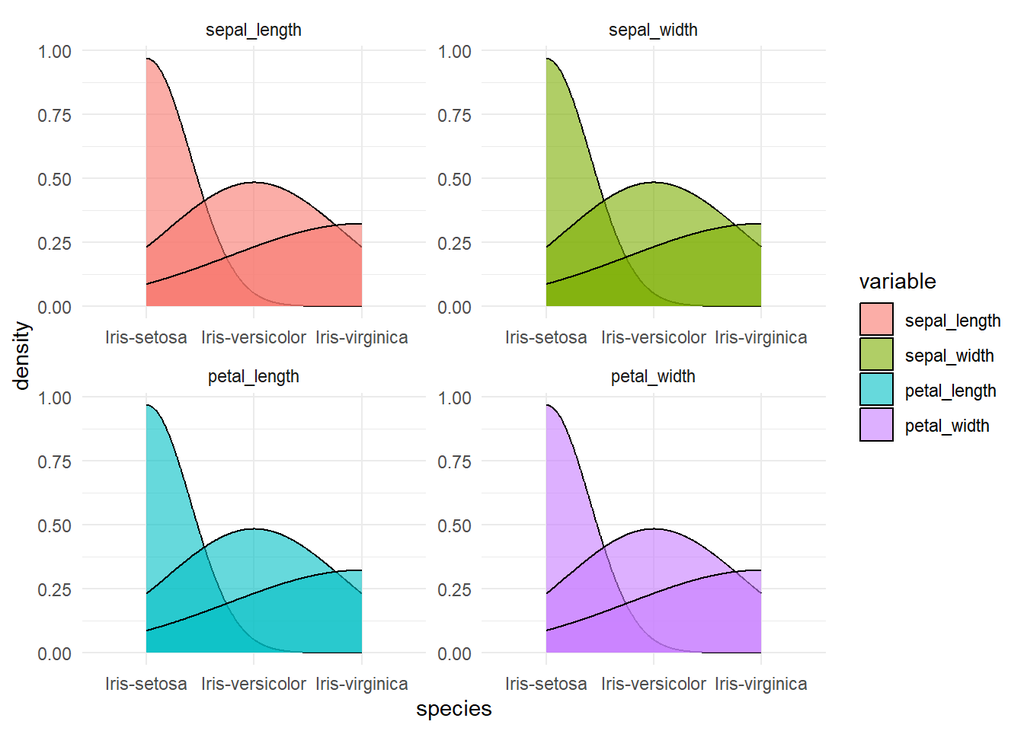

```r
ggplot(data_long, aes(species, fill= variable))+
  geom_density(alpha=0.6)+
  facet_wrap(~variable, scales = "free")+
  theme_minimal()
```

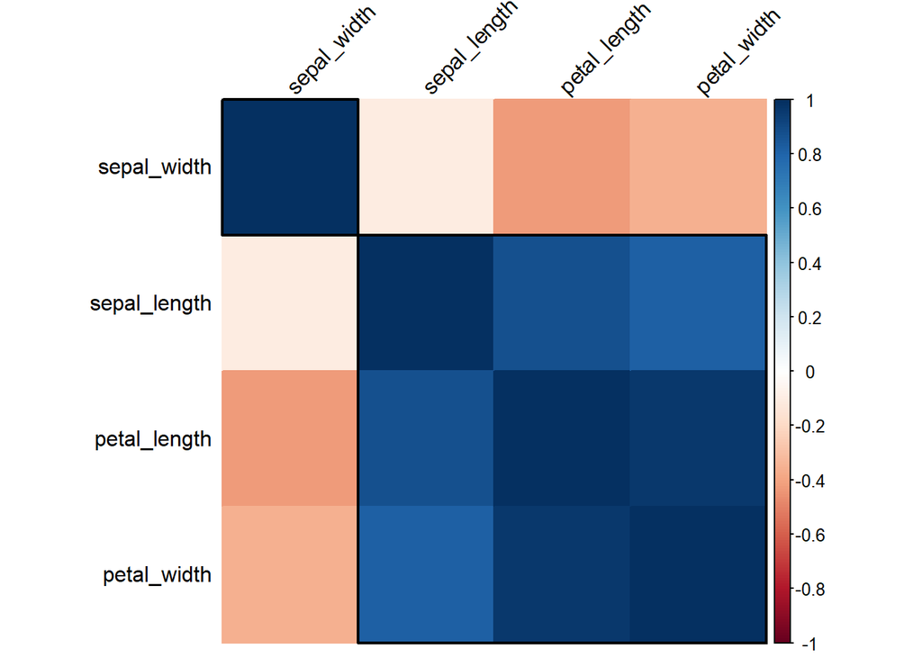

```r
cor_matrix <- cor(iris[, -5])
corrplot(cor_matrix, method = "color", type = "full", order = "hclust", tl.col="black", tl.srt = 45, addrect = 2)
```

```r
###Changing the species into factor
iris$species <- factor(iris$species)
```

Changing the species variable into a factor to make it easier to run through a predictive model.

```r
###Splitting the data
set.seed(101)
sample <- sample.split(iris$species, SplitRatio = 0.5)

Iristest <- subset(iris, sample == FALSE)
Iristrain <- subset(iris, sample == TRUE)
```

Splitting the data into training data, which will be used to train the predictive model. Then, use the testing data to run the prediction.

```r
###Modeling the data
traindata <- Iristrain[,1:4]
trainclass <- Iristrain[,5]
tr <- trainControl(method = "cv", number = 5, savePredictions = TRUE)
IrisPredict <- train(traindata, trainclass,
              method = "rpart",
              trControl = tr)

confusionMatrix(IrisPredict)
```

```
## Cross-Validated (5 fold) Confusion Matrix
##
## (entries are percentual average cell counts across resamples)
##
##                  Reference
## Prediction        Iris-setosa Iris-versicolor Iris-virginica
##   Iris-setosa            33.3             0.0            0.0
##   Iris-versicolor         0.0            30.7            5.3
##   Iris-virginica          0.0             2.7           28.0
##
##  Accuracy (average) : 0.92
```

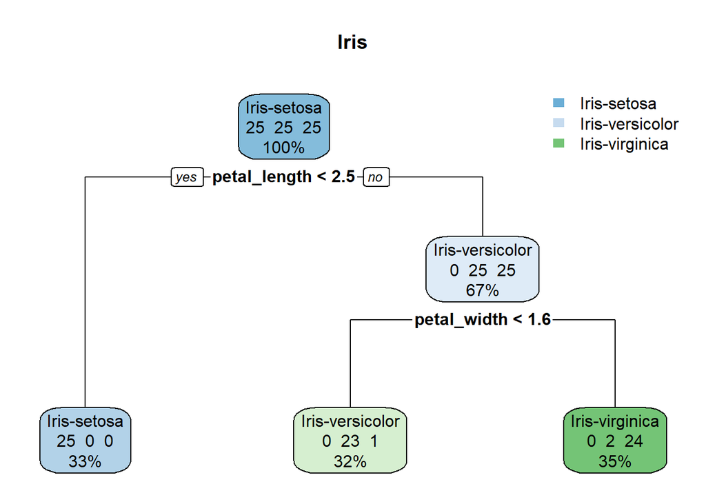

```r
rpart.plot(IrisPredict$finalModel, box.palette = "BuGn",main = "Iris", extra = 101)
```

```r
rpart.rules(IrisPredict$finalModel, cover = TRUE, clip.facs = TRUE)
```

```
##         .outcome  Iris Iris Iris                                                  cover
##      Iris-setosa [1.00  .00  .00] when petal_length <  2.5                          33%
##  Iris-versicolor [ .00  .96  .04] when petal_length >= 2.5 & petal_width <  1.6     32%
##   Iris-virginica [ .00  .08  .92] when petal_length >= 2.5 & petal_width >= 1.6     35%
```

```r
TestPredict <- rpart.predict(IrisPredict,Iristest)

table(TestPredict, Iristest$species) %>%
  prop.table()%>%
  round(3)
```

```
##
## TestPredict       Iris-setosa Iris-versicolor Iris-virginica
##   Iris-setosa           0.333           0.000          0.000
##   Iris-versicolor       0.000           0.293          0.027
##   Iris-virginica        0.000           0.040          0.307
```

## Confusion Matrix

When the training data was used, the average accuracy of the confusion matrix is 92%.

## Predicition

When checking the prediction using test data, the proportion indicate that the prediction are not too far off.